# RED WINE EXPLORATION BY EMAN ALMAARI

This dataset contains 1,599 red wines with 13 variables on the chemical properties of the wine. Wine experts rated the quality of each wine, providing a rating between 0 (very bad) and 10 (very excellent).

# Univariate Plots Section

The distribution of each variale will be analyzed using histogram also the summary statistic will be provided (mean , median and quartile). For each variable we will calculate correlation with quality to see which variable has an effect on quality

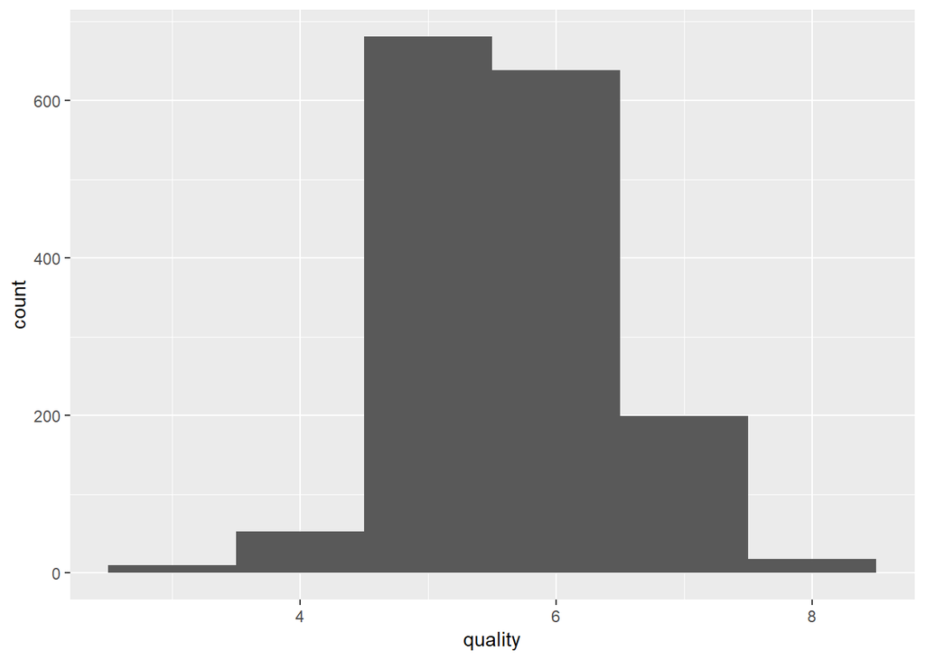

```
##    Min. 1st Qu.  Median    Mean 3rd Qu.    Max.
##   3.000   5.000   6.000   5.636   6.000   8.000
```

From the plot and the summary, we can see that the distribution of quality is normal and most of the wine has quality between 5 and 6

We can create a column to group the quality rating into 3 groups: low (3-4), medium (5-6), high (7-8).

```r
red_wine$quality_groups <- ifelse(red_wine$quality < 5, 'low (3-4)',
                   ifelse(red_wine$quality < 7, 'medium (5-6)',
                   'high (7-8)'))
```

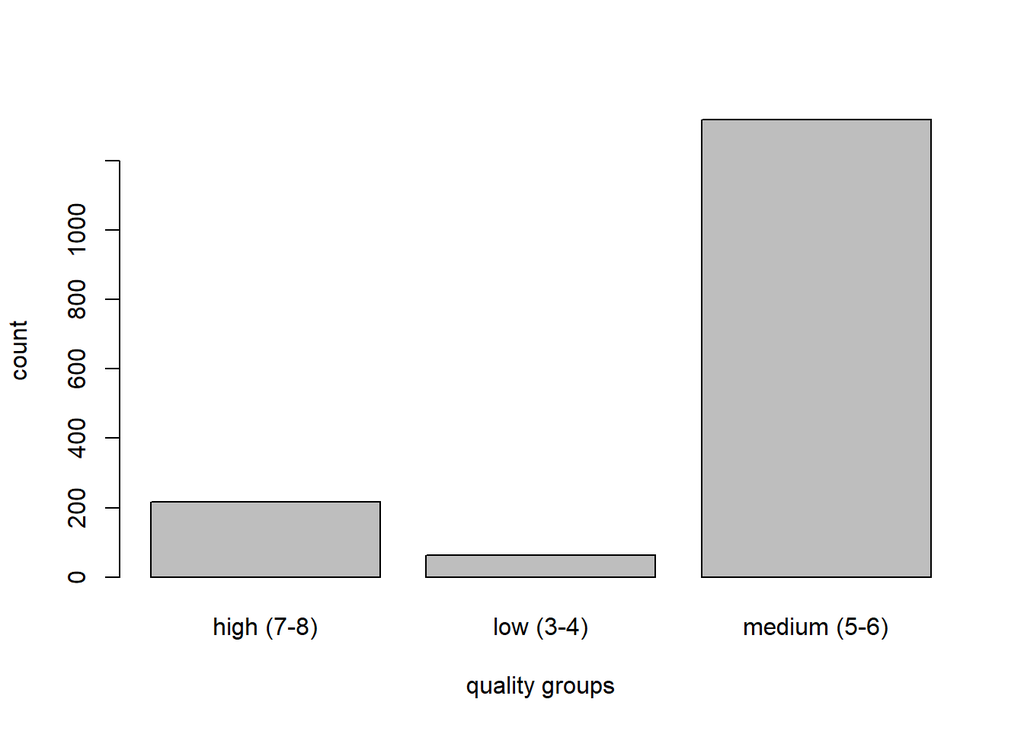

As stated before, most of the quality ratings fall in the medium group..